# Generalized Procrustes Analysis

06 de Dezembro de 2014

## Preliminares

## O que é a GPA?

A GPA ('Generalized Procrustes Analysis') consiste em realizar uma série de operações sobre um conjunto de configurações de marcos, de maneira a remover deste conjunto aquela variação que não é informativa do ponto de vista biológico:

- Translação;
- Rotação;
- Escala.

## Mas…

Variação em escala é importante do ponto de vista biológico.

A GPA nos permite separar a variação associada à escala daquela associada à forma, de modo que é possível estimar efeitos alométricos sobre a variação de forma.

**Alometria**: associação entre um caráter de interesse (morfológico, fisiológico, ou até mesmo ecológico) e tamanho corporal (Huxley 1932).

## Passo a Passo

- \(k\): número de marcos anatômicos
- \(m\): dimensões
- \(n\): número de indivíduos

Zelditch et al. (2004)

## Centróide

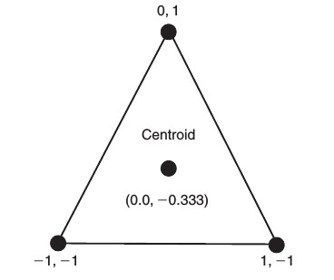

\[C_j = \frac{1}{k}\sum_{i=1}^{k}X_{ij}\]

```r
X <- matrix(c(-1, -1, 1, -1, 0, 1), nrow = 3, byrow = T)
X
```

```
##      [,1] [,2]
## [1,]   -1   -1
## [2,]    1   -1
## [3,]    0    1
```

```r
colMeans(X)
```

```
## [1]  0.0000000 -0.3333333
```

## Tamanho do Centróide

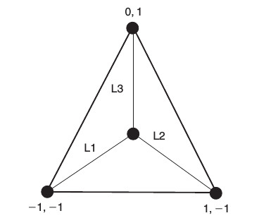

\[CS(X) = \sqrt{\sum_{i=1}^{k}\sum_{j=1}^{m}(X_{ij} - C_j)^2}\]

```r
centroid.size(X)
```

```
## [1] 2.160247
```

Assim, o tamanho do centróide é a variável que representa a variação de escala.

Bookstein (1991) demonstrou que o \(CS\) é uma variável "pura" de tamanho.

Para remover o efeito do tamanho das coordenadas cartesianas, podemos simplesmente dividir cada coordenada de cada *landmark* de uma configuração pelo tamanho do centróide.

```r
X.norm <- X / centroid.size(X)
X.norm
```

```
##          [,1]     [,2]
## [1,] -0.46291 -0.46291
## [2,]  0.46291 -0.46291
## [3,]  0.00000  0.46291
```

```r
centroid.size(X.norm)
```

```
## [1] 1
```

## Exemplo Mínimo

Vamos seguir os passos referentes à GPA no exemplo mínimo de dois triângulos. Neste caso, o procedimento é chamado de "Ordinary Procrustes Analysis".

\[ X = \begin{bmatrix} -1 & -1 \\ 1 & -1 \\ 0 & 1 \\ \end{bmatrix} \qquad W = \begin {bmatrix} 1.07 & -1.64 \\ 3.10 & -0.72 \\ 1.55 & 0.82 \\ \end{bmatrix} \]

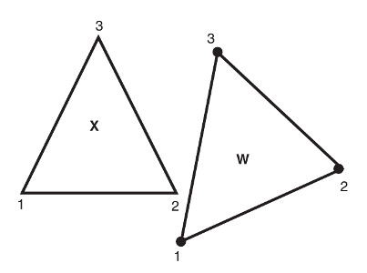

## Translação

Esta operação lida com aquela variação proveniente do posicionamento.

```r
X
```

```
##      [,1] [,2]
## [1,]   -1   -1
## [2,]    1   -1
## [3,]    0    1
```

```r
W <- matrix (c(1.07, -1.64, 3.1, -0.72, 1.55, 0.82),  nrow = 3, byrow = TRUE)
W
```

```
##      [,1]  [,2]
## [1,] 1.07 -1.64
## [2,] 3.10 -0.72
## [3,] 1.55  0.82
```

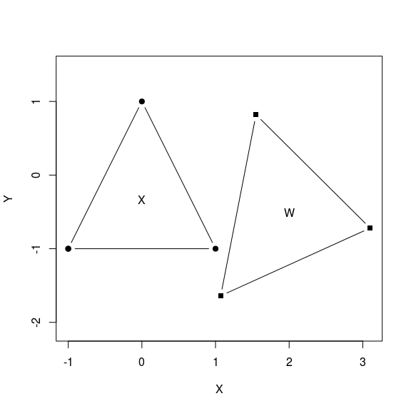

A operação é relativamente simples: nós apenas subtraímos a posição do centróide de cada configuração de suas coordenadas, efetivamente deslocando o centróide de todas as configurações para o par \((0, 0)\).

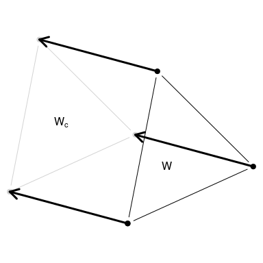

A função *scale* dá conta de fazer isso:

```r
X.center <- scale(X, center = TRUE, scale = FALSE)
X.center
```

```
##      [,1]       [,2]
## [1,]   -1 -0.6666667
## [2,]    1 -0.6666667
## [3,]    0  1.3333333
## attr(,"scaled:center")
## [1]  0.0000000 -0.3333333
```

```r
W.center <- scale(W, center = TRUE, scale = FALSE)
W.center
```

```
##            [,1]       [,2]
## [1,] -0.8366667 -1.1266667
## [2,]  1.1933333 -0.2066667
## [3,] -0.3566667  1.3333333
## attr(,"scaled:center")
## [1]  1.9066667 -0.5133333
```

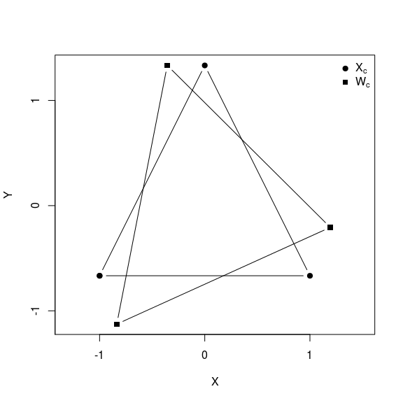

## Escalonamento

Vamos escalonar ambos \(X\) e \(W\), desta vez guardando o \(CS\) de cada configuração.

```r
cs.X <- centroid.size(X)
cs.X
```

```
## [1] 2.160247
```

```r
X.centerscale <- X.center / cs.X
X.centerscale
```

```
##          [,1]       [,2]
## [1,] -0.46291 -0.3086067
## [2,]  0.46291 -0.3086067
## [3,]  0.00000  0.6172134
## attr(,"scaled:center")
## [1]  0.0000000 -0.3333333
```

```r
cs.W <- centroid.size(W)
cs.W
```

```
## [1] 2.311089
```

```r
W.centerscale <- W.center / cs.W
W.centerscale
```

```
##            [,1]        [,2]
## [1,] -0.3620227 -0.48750462
## [2,]  0.5163510 -0.08942392
## [3,] -0.1543284  0.57692854
## attr(,"scaled:center")
## [1]  1.9066667 -0.5133333
```

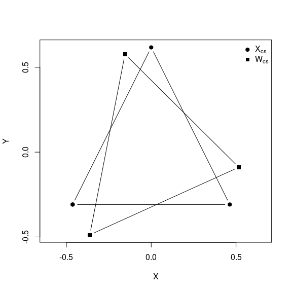

## Rotação

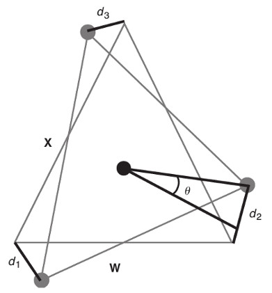

O que nós queremos é encontrar o ângulo \(\theta\) que, ao rotacionar o triângulo \(W\), minimiza a quantidade

\[D = \sqrt{d_1^2 + d_2^2 + d_3^2}\]

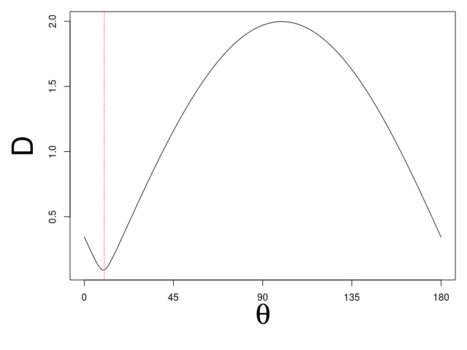

Multiplicamos a configuração \(W_{cs}\) por uma matriz de rotação

\[R = \begin {bmatrix} cos \theta & sen \theta \\ - sen \theta & cos \theta \\ \end{bmatrix}\]

```r
W.csr <- W.centerscale %*% R
W.csr
```

```
##             [,1]       [,2]
## [1,] -0.50206576 -0.3415423
## [2,]  0.45832830 -0.2540673
## [3,]  0.04373747  0.5956096
```

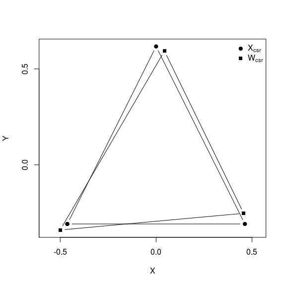

## OPA para GPA

No caso de mais de dois objetos, o procedimento chama-se GPA de fato.

- Escalonamento e Translação: Idênticos
- Rotação: Processo Iterativo

## Propriedades do Espaço da Forma

Em duas dimensões, é necessário estimar, para cada configuração de marcos, quatro parâmetros:

- Posição do Centróide (\(x_C\), \(y_C\));
- Tamanho do Centróide (\(CS\));
- Ângulo de Rotação (\(\theta\)).

Em geral, estimamos \(m + \frac{m(m-1)}{2} + 1\) parâmetros. Por exemplo, em três dimensões, sete parâmetros são estimados.

## Propriedades do Espaço da Forma

Assim sendo, o procedimento tem duas consequências importantes:

- \(m + \frac{m(m-1)}{2} + 1\) graus de liberdade são perdidos;
- A geometria do morfoespaço gerado pelas transformações não é euclidiana (por conta da restrição \(CS(X_i) = 1\)).

Vamos ilustrar estas propriedades em um exemplo onde construímos 10000 triângulos, submetendo estes à GPA.

## Propriedades do Espaço da Forma

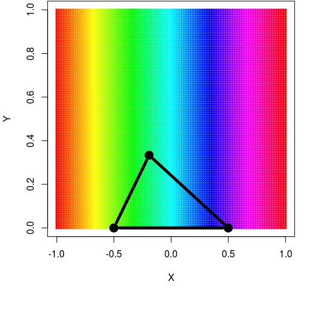

## Propriedades do Espaço da Forma

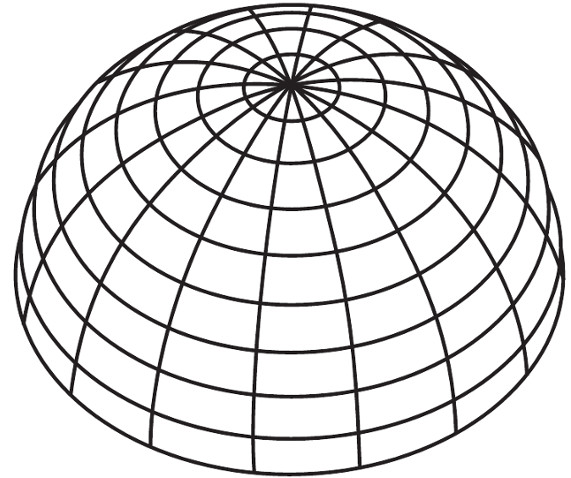

## Espaço Tangente

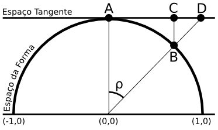

- Distância de Procrustes: Distância (em arco) entre duas formas;
- Por exemplo, a distância entre a forma de referência (média) \(A\) e uma forma \(B\) qualquer (\(\rho\));
- Diferentes projeções podem ser definidas:
  - Ortográfica (\(C\));
  - Estereográfica (\(D\)).

## Espaço Tangente

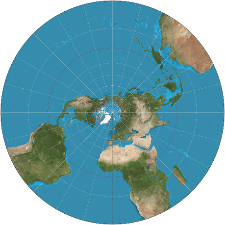

Projeção Estereográfica

## Espaço Tangente

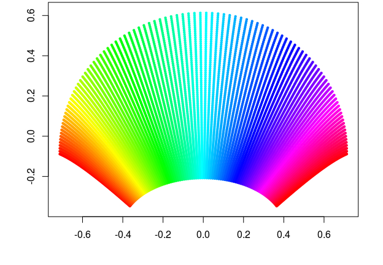

Projeção Ortográfica

## Espaço Tangente

Assim, podemos comparar a Distância de Procrustes \(\rho\) com a distância euclidiana calculada no espaço tangente, observando que, quanto mais distantes estivermos da forma de referência, maiores serão as diferenças entre as duas distâncias.

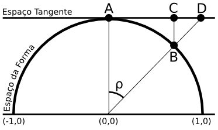

Vamos observar a relação entre \(\rho\) e \(AC\) no nosso exemplo.

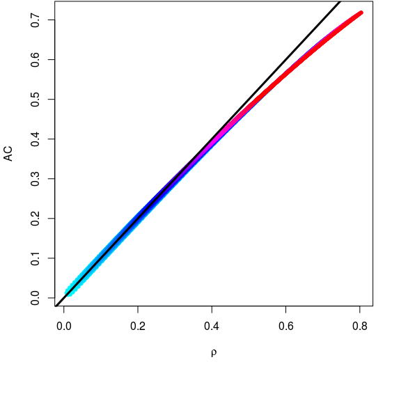

## Consequencias Práticas da GPA

- TODA inferência estatística é construída sobre a premissa que o espaço que as observações ocupam é euclidiano. Assim, se queremos utilizar técnicas paramétricas de estatística, temos de usar projeções no espaço da tangente.
- Nossas variáveis de forma (resíduos da tangente) sempre terão uma dimensionalidade menor do que aquela representada pelo número de variáveis.
- Dessa forma, para lidarmos com variáveis de forma do ponto de vista da inferência estatística, devemos nos valer de técnicas de redução de dimensionalidade (PCA, TPS).

## Thin Plate Splines

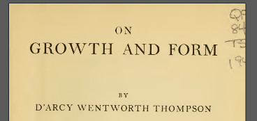

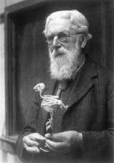

D'Arcy Thompson

[figure not shown]

Thompson (1917) propõe a representação de formas através de grades de deformação.

[figure not shown]

[figure not shown]

Fred L. Bookstein

Bookstein (1989) introduziu o formalismo físico-matemático para a estimativa de grades de deformação entre uma forma de referência e uma forma-alvo.

- Modelo físico de comportamento da variação morfológica;
- Transformação atráves de dobramentos em uma placa metálica fina;
- Minimizar a energia de dobramento.

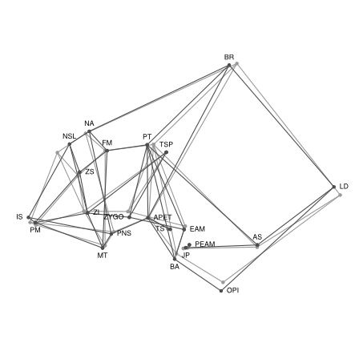

- Cinza: Referência
- Preto: Alvo

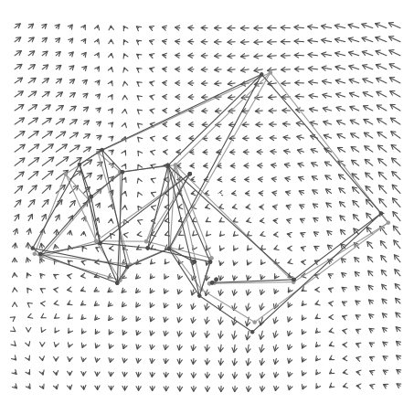

## Exemplo

```r
data(digit3.dat)
gpa3 <- gpagen(digit3.dat, ShowPlot = FALSE)
str(gpa3)
```

```
## List of 2
##  $ coords: num [1:13, 1:2, 1:30] -0.182 -0.26 -0.334 -0.331 -0.237 ...
##  $ Csize : num [1:30] 56.3 35.2 31.7 45.4 44.9 ...
```

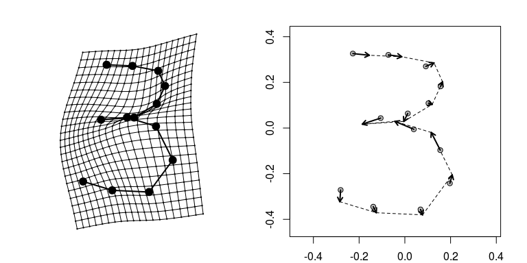

```r
par (mfrow = c (1, 2), mar = c(2, 2, 2, 2))
plotRefToTarget(mshape (gpa3 $ coords), gpa3 $ coords [, , 12],
                links = cbind (1:12, 2:13), method = 'TPS')
plotRefToTarget(mshape (gpa3 $ coords), gpa3 $ coords [, , 12],
                links = cbind (1:12, 2:13), method = 'vector')
```

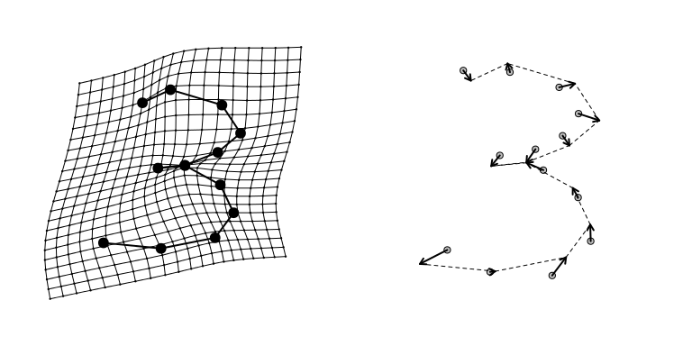

```r
par (mfrow = c (1, 2), mar = c(2, 2, 2, 2), bty = 'n', xaxt = 'n', yaxt = 'n')
plotRefToTarget(mshape (gpa3 $ coords), gpa3 $ coords [, , 18],
                links = cbind (1:12, 2:13), method = 'TPS')
plotRefToTarget(mshape (gpa3 $ coords), gpa3 $ coords [, , 18],
                links = cbind (1:12, 2:13), method = 'vector')
```

## Resumindo

- TPS possibilita a visualização de variação morfológica de uma forma mais clara;
- as deformações podem ser utilizadas como variáveis (mas aqui a gente não vai fazer isso);
- outras funções de interpolação podem ser utilizadas para modelar o comportamento dos tecidos ao redor dos *landmarks*.

## Semilandmarks

## Formas sem *Landmarks*

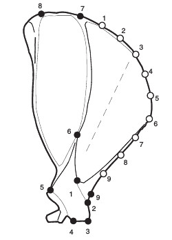

- Em certos casos, a variação morfológica de interesse não pode ser representada exclusivamente por *landmarks*;
- Podemos recorrer à definição de *semilandmarks*, que definem uma curva homóloga em toda amostra;
- Apesar da curva ser homóloga, a posição de cada *semilandmark* sobre a curva não é homóloga na amostra.

## Deslizando

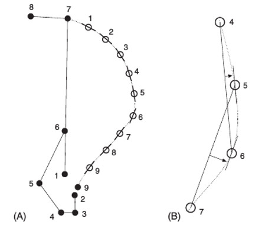

## Deslizando

A posição dos *semilandmarks* pode ser otimizada com base em dois critérios:

- Distância de Procrustes;
- Energia Mínima de Dobramento (TPS).

## Cobertura

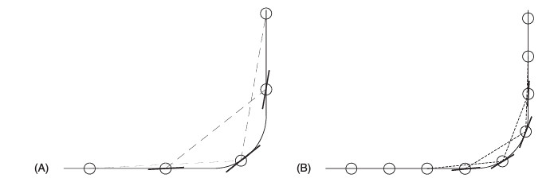

- Aumentar a cobertura nos permite uma representação mais fidedigna da curva em questão.
- No entanto, devemos considerar que aumentar o número de variáveis implica em problemas associados ao número de graus de liberdade e tamanho amostral.

## Bibliografia

Bookstein, F L. 1989. “Principal Warps: Thin Plate Splines and the Decomposition of Deformations.” *IEEE Transactions on Pattern Analysis and Machine Intelligence* 11 (6): 567–85.

———. 1991. *Morphometric Tools for Landmark Data: geometry and Biology*. Cambridge: Cambridge University Press.

Huxley, J S. 1932. *Problems of Relative Growth*.

Thompson, D W. 1917. *On Growth and Form.* Cambridge University Press.

Zelditch, M L, D L Swiderski, H D Sheets, and W L Fink. 2004. *Geometric Morphometrics for Biologists: A Primer*. 1st ed. Elsevier.